# CS145: Project 3 | Predicting COVID Culmulative Confirmed Cases on County Level

## Project Overview

*This project tries to predict number of COVID culmulative confirmed cases on county level, base on its correlation with historical COVID matrices, population and local mobility trend.*

*By training a linear regression model with data between April and August 2020, below results were achieved:*

| Method | Data | mean_absolute_error | median_absolute_error |
| --- | --- | --- | --- |
| Evaluation | Sep 1st to 30th | 7.52 | 2.08 |
| Evaluation | Oct 1st to 31st | 9.63 | 2.81 |
| Prediction | Nov 1st to 7th | 15.95 | 3.99 |

The mean absolute error rate for prediction, calcuated as mean of absolute error divided by corresponding ground truth, is 1.66%. Benchmarking Google Forecast on County level, the mean absolute error rate is 10.04%. Code in appendix.

*In the model, a total of 60 features where used:*

- **Historical Culmulative Confirmed:** lag1 to lag28 represents culmulative confirmed cases from yesterday (lag1) to 28 days ago (lag28)
- **Historical Culmulative Deceased:** dlag1 to dlag14 represents culmulative deceased cases from yesterday (dlag1) to 14 days ago (dlag14)
- **Population:** a_1 to a_18 represents population by age group from age 0 to 4 (a_1) to age 85 or above (a_18)

## Analysis of Dataset

### a. Create tables

*This project utilizes Google BigQuery Open datasets ane one external dataset:*

1. covid19_open_data, table `covid19_open_data`, size 1.34 GB (extracted on Nov 11, 2020, contains COVID matrices updated to Nov 07, 2020)
2. covid open data, table `index` and `geography`, size 2.54 MB ([source and documentation](https://github.com/GoogleCloudPlatform/covid-19-open-data))
3. geo_us_boundaries, table `adjacent_counties`, size 588.08 KB
4. External table from census with estimated population for counties, with race and age group, size 168 MB ([source](https://www2.census.gov/programs-surveys/popest/datasets/2010-2019/counties/asrh/cc-est2019-alldata.csv), [documentation](https://www2.census.gov/programs-surveys/popest/technical-documentation/file-layouts/2010-2019/cc-est2019-alldata.pdf)).

*Two tables are created by extracting useful data: `covid` and `pop_est2019`. After some manuipulation, the resulting tables are 128.96 MB and 38.15 MB respectively.*

*Two other tables `index_county` and `geo` were created to serve data matching purpose. Table `pop_age` were created by transposing data in R for population by age.*

```python
# create table "covid" from covid19_open_data for number of cases and potential features

SELECT    date, location_key,                                   # primary key
          subregion1_code, subregion2_code, subregion1_name, subregion2_name,
          new_confirmed, new_deceased, new_recovered, new_tested,
          cumulative_confirmed, cumulative_deceased, cumulative_recovered, cumulative_tested,
          new_hospitalized_patients, new_intensive_care_patients, new_ventilator_patients,
          cumulative_hospitalized_patients, cumulative_intensive_care_patients, cumulative_ventilator_patients,
          current_hospitalized_patients, current_intensive_care_patients, current_ventilator_patients,
          mobility_transit_stations, mobility_retail_and_recreation, mobility_grocery_and_pharmacy,
          mobility_parks, mobility_residential, mobility_workplaces,
          average_temperature_celsius, minimum_temperature_celsius, maximum_temperature_celsius,
          rainfall_mm, snowfall_mm
FROM      `bigquery-public-data.covid19_open_data.covid19_open_data`
WHERE     lower(location_key) LIKE "us%"
```

```python
# step 1: create table "pop_est2019" from census data

SELECT  * EXCEPT (SUMLEV, YEAR)
FROM    `cs145-proj-3.covid.county_est2019`         # original file includes data from 2010 to 2019
WHERE   YEAR = 12                                   # year 12 = 7/1/2019 population estimate

# step 2: create key and foriegn key "county_code" for "pop_est2019"

# step2_1: create string value county_code

UPDATE  `cs145-proj-3.covid.pop_est2019`
SET     county_code = CONCAT( RIGHT (SAFE_CAST( 100 + STATE AS STRING) , 2), RIGHT (SAFE_CAST(1000 + COUNTY AS STRING) ,3 ))
WHERE   TRUE

# step2_2: create key base on external key county_code

UPDATE  `cs145-proj-3.covid.pop_est2019` AS p
SET     p.location_key = i.key
FROM    `cs145-proj-3.covid.index_county` AS i      # using Google Open Data Index Table
WHERE   p.county_code = i.subregion2_code
```

### b. Table `covid`

*Table `covid` has a multiple key made up by `date` and `location_key`.*

*`location_key` is the foreign key that connects to table `geo` and table `pop_est2019`.*

*This table contains the target value `cumulative_confirmed`, and input values in below categories:*

### c. Table `pop_est_2019`

*Table `pop_est_2019` has a multiple key made up by `location_key` and `AGEGRP`.*

*This table contains input features in population, including:*

- **Total:** where age group = 0
- **Age Group:** Total 18 groups, from age 0 to 4, to age 85 or above
- **Gender:** male, female
- **RACE (alone):** White, Black or African American, American Indian and Alaska Native, Asian, Native Hawaiian and Other Pacific Islander. All in male and female categories and by age group.
- **RACE (combined):** various combination race including Hispanic and Non-Hispanic categories.

### d. Highlevel Findings

#### Top 10 Counties with Most Confirmed Cases

```python
%%bigquery --project $project_id

SELECT    subregion1_name, subregion2_name,
          MAX(cumulative_confirmed) AS tot_cases
FROM      `cs145-proj-3.covid.covid`
WHERE     subregion2_code IS NOT NULL
          AND date <= "2020-11-07"
GROUP BY  location_key, subregion1_name, subregion2_name
ORDER BY  tot_cases DESC
LIMIT     10
```

|  | subregion1_name | subregion2_name | tot_cases |
| --- | --- | --- | --- |
| 0 | California | Los Angeles County | 320048 |
| 1 | Illinois | Cook County | 214924 |
| 2 | Florida | Miami-Dade County | 193070 |
| 3 | Texas | Harris County | 166545 |
| 4 | Arizona | Maricopa County | 165702 |
| 5 | Texas | Dallas County | 108631 |
| 6 | Florida | Broward County | 90802 |
| 7 | Nevada | Clark County | 88015 |
| 8 | New York | Queens County | 77994 |
| 9 | New York | Kings County | 75968 |

#### Top 10 Counties with Most COVID Death

```python
%%bigquery --project $project_id

SELECT    subregion1_name, subregion2_name,
          MAX(cumulative_deceased) AS tot_death
FROM      `cs145-proj-3.covid.covid`
WHERE     subregion2_code IS NOT NULL
          AND date <= "2020-11-07"
GROUP BY  location_key, subregion1_name, subregion2_name
ORDER BY  tot_death DESC
LIMIT     10
```

|  | subregion1_name | subregion2_name | tot_death |
| --- | --- | --- | --- |
| 0 | California | Los Angeles County | 7170 |
| 1 | New York | Queens County | 6056 |
| 2 | New York | Kings County | 5780 |
| 3 | Illinois | Cook County | 5770 |
| 4 | New York | Bronx County | 4070 |
| 5 | Arizona | Maricopa County | 3699 |
| 6 | Florida | Miami-Dade County | 3682 |
| 7 | Michigan | Wayne County | 3086 |
| 8 | Texas | Harris County | 2865 |
| 9 | New York | Nassau County | 2706 |

#### Top 10 Counties with Highest Infection Rate

```python
%%bigquery --project $project_id

SELECT    c.subregion1_name, c.subregion2_name,
          c.tot_cases, p.pop,
          ROUND(c.tot_cases / p.pop * 100,2) AS rate_infection
FROM      (SELECT   location_key, TOT_POP AS pop
          FROM      `cs145-proj-3.covid.pop_est2019`
          WHERE     AGEGRP = 0) AS p,
          (SELECT    location_key, subregion1_name, subregion2_name,
                   MAX(cumulative_confirmed) AS tot_cases
          FROM      `cs145-proj-3.covid.covid`
          WHERE     subregion2_code IS NOT NULL
                    AND date <= "2020-11-07"
          GROUP BY  location_key, subregion1_name, subregion2_name) AS c
WHERE     p.location_key = c.location_key
ORDER BY  rate_infection DESC
LIMIT     10
```

|  | subregion1_name | subregion2_name | tot_cases | pop | rate_infection |
| --- | --- | --- | --- | --- | --- |
| 0 | Arkansas | Lincoln County | 2355 | 13024 | 18.08 |
| 1 | Kansas | Norton County | 934 | 5361 | 17.42 |
| 2 | Georgia | Chattahoochee County | 1856 | 10907 | 17.02 |
| 3 | South Dakota | Bon Homme County | 1149 | 6901 | 16.65 |
| 4 | Tennessee | Trousdale County | 1828 | 11284 | 16.20 |
| 5 | South Dakota | Buffalo County | 302 | 1962 | 15.39 |
| 6 | Florida | Lafayette County | 1290 | 8422 | 15.32 |
| 7 | Tennessee | Lake County | 1026 | 7016 | 14.62 |
| 8 | Nebraska | Dakota County | 2738 | 20026 | 13.67 |
| 9 | Iowa | Buena Vista County | 2500 | 19620 | 12.74 |

## Data Exploration

*In this part, we explore the correlation between confirmed cases and various features in three catgories: population, mobilty and COVID matrices. In some cases, the correlation with cumulated death is also showcased for comparison.*

```python
# Run this cell to authenticate yourself to BigQuery
from google.colab import auth
auth.authenticate_user()
project_id = "cs145-proj-3"
```

```python
# Initialize BiqQuery client
from google.cloud import bigquery
client = bigquery.Client(project=project_id)
```

```python
# Add imports for any visualization libraries you may need
import pandas as pd
import matplotlib.pyplot as plt
import plotnine as ggplot
import numpy as np

%matplotlib inline
```

### a. Populations

*As expected, total cumulative confirmed cases at later stage is highly correlated to total population. But as we deep dive into different segmentations in popuplations, it is found that the correlation with maximum cumulative confirmed cases varies between groups.*

#### a1. Number of Infections vs Total Population

```python
%%bigquery --project $project_id a1

SELECT    c.tot_cases, p.pop
FROM      (SELECT   location_key, TOT_POP AS pop
          FROM      `cs145-proj-3.covid.pop_est2019`
          WHERE     AGEGRP = 0) AS p,
          (SELECT   location_key, subregion1_name, subregion2_name,
                    MAX(cumulative_confirmed) AS tot_cases
          FROM      `cs145-proj-3.covid.covid`
          WHERE     subregion2_code IS NOT NULL
                    AND date <= "2020-11-07"
          GROUP BY  location_key, subregion1_name, subregion2_name) AS c
WHERE     p.location_key = c.location_key
```

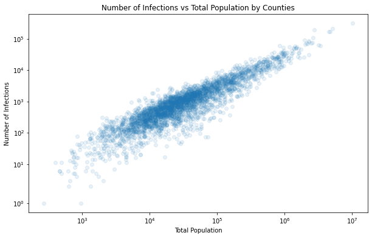

```python
plt.figure(figsize=(10, 6))
plt.scatter(a1["pop"], a1["tot_cases"], alpha=0.1)
plt.title("Number of Infections vs Total Population by Counties")
plt.xlabel("Total Population")
plt.xscale("symlog")
plt.ylabel("Number of Infections")
plt.yscale("symlog")
```

```python
%%bigquery --project $project_id

SELECT    CORR(c.tot_cases, p.pop) AS COR_infection,
          CORR(c.tot_deaths, p.pop) AS COR_death
FROM      (SELECT   location_key, TOT_POP AS pop
          FROM      `cs145-proj-3.covid.pop_est2019`
          WHERE     AGEGRP = 0) AS p,
          (SELECT   location_key, subregion1_name, subregion2_name,
                    MAX(cumulative_confirmed) AS tot_cases,
                    MAX(cumulative_deceased) AS tot_deaths
          FROM      `cs145-proj-3.covid.covid`
          WHERE     subregion2_code IS NOT NULL
                    AND date <= "2020-11-07"
          GROUP BY  location_key, subregion1_name, subregion2_name) AS c
WHERE     p.location_key = c.location_key
```

|  | COR_infection | COR_death |
| --- | --- | --- |
| 0 | 0.949515 | 0.841369 |

#### a2. Number of Infections vs Population Density

```python
%%bigquery --project $project_id a2

SELECT    c.tot_cases, (p.pop/g.area) AS pop_density
FROM      (SELECT   key, area
          FROM      `cs145-proj-3.covid.geo`) AS g,
          (SELECT   location_key, TOT_POP AS pop
          FROM      `cs145-proj-3.covid.pop_est2019`
          WHERE     AGEGRP = 0) AS p,
          (SELECT   location_key, subregion1_name, subregion2_name,
                    MAX(cumulative_confirmed) AS tot_cases
          FROM      `cs145-proj-3.covid.covid`
          WHERE     subregion2_code IS NOT NULL
                    AND date <= "2020-11-07"
          GROUP BY  location_key, subregion1_name, subregion2_name) AS c
WHERE     p.location_key = c.location_key
          AND g.key = p.location_key
```

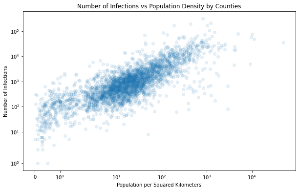

```python
plt.figure(figsize=(10, 6))
plt.scatter(a2["pop_density"], a1["tot_cases"], alpha=0.1)
plt.title("Number of Infections vs Population Density by Counties")
plt.xlabel("Population per Squared Kilometers")
plt.xscale("symlog")
plt.ylabel("Number of Infections")
plt.yscale("symlog")
```

```python
%%bigquery --project $project_id

SELECT    CORR(c.tot_cases, (p.pop/g.area)) AS COR_infected,
          CORR(c.tot_deaths, (p.pop/g.area)) AS COR_death,
FROM      (SELECT   key, area
          FROM      `cs145-proj-3.covid.geo`) AS g,
          (SELECT   location_key, TOT_POP AS pop
          FROM      `cs145-proj-3.covid.pop_est2019`
          WHERE     AGEGRP = 0) AS p,
          (SELECT   location_key, subregion1_name, subregion2_name,
                    MAX(cumulative_confirmed) AS tot_cases,
                    MAX(cumulative_deceased) AS tot_deaths
          FROM      `cs145-proj-3.covid.covid`
          WHERE     subregion2_code IS NOT NULL
                    AND date <= "2020-11-07"
          GROUP BY  location_key, subregion1_name, subregion2_name) AS c
WHERE     p.location_key = c.location_key
          AND g.key = p.location_key
```

|  | COR_infected | COR_death |
| --- | --- | --- |
| 0 | 0.198875 | 0.365826 |

#### a3. Number of Infections vs Male/Female Population

```python
%%bigquery --project $project_id a3

SELECT    c.tot_cases, p.male, p.female
FROM      (SELECT   location_key,
                    TOT_MALE AS male,
                    TOT_FEMALE AS female
          FROM      `cs145-proj-3.covid.pop_est2019`
          WHERE     AGEGRP = 0) AS p,
          (SELECT    location_key, subregion1_name, subregion2_name,
                   MAX(cumulative_confirmed) AS tot_cases
          FROM      `cs145-proj-3.covid.covid`
          WHERE     subregion2_code IS NOT NULL
                    AND date <= "2020-11-07"
          GROUP BY  location_key, subregion1_name, subregion2_name) AS c
WHERE     p.location_key = c.location_key
```

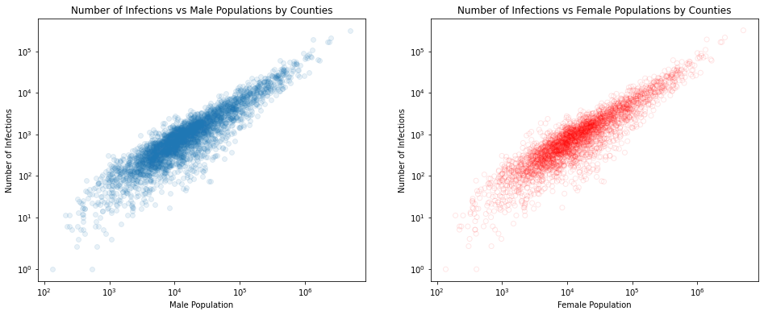

```python
plt.figure(figsize=(16, 6))

plt.subplot(1, 2, 1)
plt.scatter(a3["male"], a3["tot_cases"], alpha=0.1)
plt.title("Number of Infections vs Male Populations by Counties")
plt.xlabel("Male Population")
plt.xscale("symlog")
plt.ylabel("Number of Infections")
plt.yscale("symlog")

plt.subplot(1, 2, 2)
plt.scatter(a3["female"], a3["tot_cases"], facecolors='none', edgecolors="red", alpha=0.1)
plt.title("Number of Infections vs Female Populations by Counties")
plt.xlabel("Female Population")
plt.xscale("symlog")
plt.ylabel("Number of Infections")
plt.yscale("symlog")
```

```python
%%bigquery --project $project_id

SELECT    CORR(c.tot_cases, p.male) AS COR_infected_male,
          CORR(c.tot_cases, p.female) AS COR_infected_female,
          CORR(c.tot_deaths, p.male) AS COR_death_male,
          CORR(c.tot_deaths, p.female) AS COR_death_female,
FROM      (SELECT   location_key,
                    TOT_MALE AS male,
                    TOT_FEMALE AS female
          FROM      `cs145-proj-3.covid.pop_est2019`
          WHERE     AGEGRP = 0) AS p,
          (SELECT    location_key, subregion1_name, subregion2_name,
                   MAX(cumulative_confirmed) AS tot_cases,
                   MAX(cumulative_deceased) AS tot_deaths
          FROM      `cs145-proj-3.covid.covid`
          WHERE     subregion2_code IS NOT NULL
                    AND date <= "2020-11-07"
          GROUP BY  location_key, subregion1_name, subregion2_name) AS c
WHERE     p.location_key = c.location_key
```

|  | COR_infected_male | COR_infected_female | COR_death_male | COR_death_female |
| --- | --- | --- | --- | --- |
| 0 | 0.948385 | 0.950391 | 0.836523 | 0.845858 |

#### a4. Number of Infections vs Populations by Age Group

```python
%%bigquery --project $project_id a4

SELECT    c.tot_cases, AGEGRP, age_group_pop
FROM      (SELECT   location_key, AGEGRP,
                    SUM(TOT_POP) AS age_group_pop
          FROM      `cs145-proj-3.covid.pop_est2019`
          WHERE     AGEGRP != 0
          GROUP BY   location_key, AGEGRP) AS p,
          (SELECT    location_key, subregion1_name, subregion2_name,
                   MAX(cumulative_confirmed) AS tot_cases
          FROM      `cs145-proj-3.covid.covid`
          WHERE     subregion2_code IS NOT NULL
                    AND date <= "2020-11-07"
          GROUP BY  location_key, subregion1_name, subregion2_name) AS c
WHERE     p.location_key = c.location_key
```

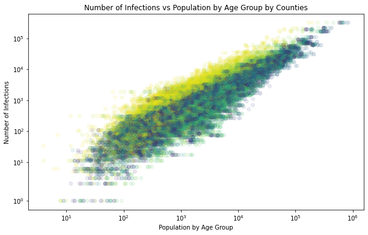

```python
plt.figure(figsize=(10, 6))
plt.scatter(a4["age_group_pop"], a4["tot_cases"], c = a4["AGEGRP"],alpha=0.1)
plt.title("Number of Infections vs Population by Age Group by Counties")
plt.xlabel("Population by Age Group")
plt.xscale("symlog")
plt.ylabel("Number of Infections")
plt.yscale("symlog")
```

```python
%%bigquery --project $project_id

SELECT    CORR(c.tot_cases, IF(AGEGRP = 1, p.age_pop, NULL)) AS COR_agegrp_01,
          CORR(c.tot_cases, IF(AGEGRP = 2, p.age_pop, NULL)) AS COR_agegrp_02,
          CORR(c.tot_cases, IF(AGEGRP = 3, p.age_pop, NULL)) AS COR_agegrp_03,
          CORR(c.tot_cases, IF(AGEGRP = 4, p.age_pop, NULL)) AS COR_agegrp_04,
          CORR(c.tot_cases, IF(AGEGRP = 5, p.age_pop, NULL)) AS COR_agegrp_05,
          CORR(c.tot_cases, IF(AGEGRP = 6, p.age_pop, NULL)) AS COR_agegrp_06,
          CORR(c.tot_cases, IF(AGEGRP = 7, p.age_pop, NULL)) AS COR_agegrp_07,
          CORR(c.tot_cases, IF(AGEGRP = 8, p.age_pop, NULL)) AS COR_agegrp_08,
          CORR(c.tot_cases, IF(AGEGRP = 9, p.age_pop, NULL)) AS COR_agegrp_09,
          CORR(c.tot_cases, IF(AGEGRP = 10, p.age_pop, NULL)) AS COR_agegrp_10,
          CORR(c.tot_cases, IF(AGEGRP = 11, p.age_pop, NULL)) AS COR_agegrp_11,
          CORR(c.tot_cases, IF(AGEGRP = 12, p.age_pop, NULL)) AS COR_agegrp_12,
          CORR(c.tot_cases, IF(AGEGRP = 13, p.age_pop, NULL)) AS COR_agegrp_13,
          CORR(c.tot_cases, IF(AGEGRP = 14, p.age_pop, NULL)) AS COR_agegrp_14,
          CORR(c.tot_cases, IF(AGEGRP = 15, p.age_pop, NULL)) AS COR_agegrp_15,
          CORR(c.tot_cases, IF(AGEGRP = 16, p.age_pop, NULL)) AS COR_agegrp_16,
          CORR(c.tot_cases, IF(AGEGRP = 17, p.age_pop, NULL)) AS COR_agegrp_17,
          CORR(c.tot_cases, IF(AGEGRP = 18, p.age_pop, NULL)) AS COR_agegrp_18
FROM      (SELECT location_key, AGEGRP, AVG(TOT_POP) AS age_pop
          FROM      `cs145-proj-3.covid.pop_est2019`
          WHERE     AGEGRP != 0
          GROUP BY  location_key, AGEGRP) AS p,
          (SELECT    location_key, subregion1_name, subregion2_name,
                   MAX(cumulative_confirmed) AS tot_cases
          FROM      `cs145-proj-3.covid.covid`
          WHERE     subregion2_code IS NOT NULL
                    AND date <= "2020-11-07"
          GROUP BY  location_key, subregion1_name, subregion2_name) AS c
WHERE     p.location_key = c.location_key
```

|  | COR_agegrp_01 | COR_agegrp_02 | COR_agegrp_03 | COR_agegrp_04 | COR_agegrp_05 | COR_agegrp_06 | COR_agegrp_07 | COR_agegrp_08 | COR_agegrp_09 | COR_agegrp_10 | COR_agegrp_11 | COR_agegrp_12 | COR_agegrp_13 | COR_agegrp_14 | COR_agegrp_15 | COR_agegrp_16 | COR_agegrp_17 | COR_agegrp_18 |
| --- | --- | --- | --- | --- | --- | --- | --- | --- | --- | --- | --- | --- | --- | --- | --- | --- | --- | --- |
| 0 | 0.953127 | 0.950586 | 0.949148 | 0.948146 | 0.943232 | 0.941175 | 0.939654 | 0.944321 | 0.94893 | 0.948329 | 0.945618 | 0.942476 | 0.937827 | 0.934207 | 0.927011 | 0.924836 | 0.925979 | 0.911602 |

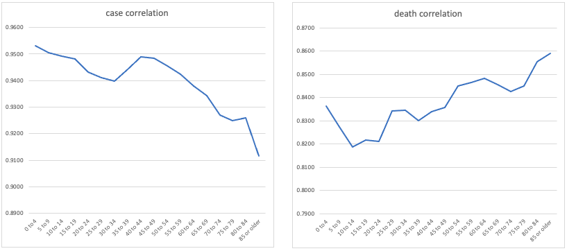

#### a5. Number of Infections vs Populations by Race

*According to census, "The sum of the five race groups adds to more than the total population because individuals may report more than one race." After checking the dataset, the difference is neglectible. Code in Appendix.*

```python
%%bigquery --project $project_id a5

SELECT    c.tot_cases,
          WA_MALE + WA_FEMALE AS WA,
          BA_MALE + BA_FEMALE AS BA,
          IA_MALE + IA_FEMALE AS IA,
          AA_MALE + AA_FEMALE AS AA,
          NA_MALE + NA_FEMALE AS NA,
          TOM_MALE + TOM_FEMALE AS TOM,
          H_MALE + H_FEMALE AS H
FROM      (SELECT   location_key,
                    WA_MALE, WA_FEMALE,
                    BA_MALE, BA_FEMALE,
                    IA_MALE, IA_FEMALE,
                    AA_MALE, AA_FEMALE,
                    NA_MALE, NA_FEMALE,
                    TOM_MALE, TOM_FEMALE,
                    H_MALE, H_FEMALE
          FROM      `cs145-proj-3.covid.pop_est2019`
          WHERE     AGEGRP = 0) AS p,
          (SELECT   location_key, subregion1_name, subregion2_name,
                    MAX(cumulative_confirmed) AS tot_cases,
                    MAX(cumulative_deceased) AS tot_death
          FROM      `cs145-proj-3.covid.covid`
          WHERE     subregion2_code IS NOT NULL
                    AND date <= "2020-11-07"
          GROUP BY  location_key, subregion1_name, subregion2_name) AS c
WHERE     p.location_key = c.location_key
```

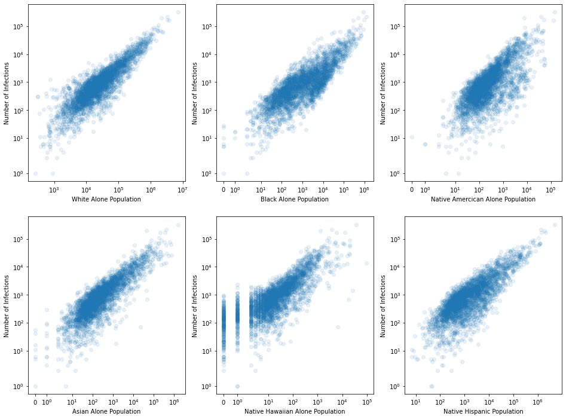

```python
plt.figure(figsize=(16, 12))

plt.subplot(2, 3, 1)
plt.scatter(a5["WA"], a5["tot_cases"], alpha=0.1)
# plt.title("Number of Infections vs White Alone Populations")
plt.xlabel("White Alone Population")
plt.xscale("symlog")
plt.ylabel("Number of Infections")
plt.yscale("symlog")

plt.subplot(2, 3, 2)
plt.scatter(a5["BA"], a5["tot_cases"], alpha=0.1)
# plt.title("Number of Infections vs Black Alone Populations")
plt.xlabel("Black Alone Population")
plt.xscale("symlog")
plt.ylabel("Number of Infections")
plt.yscale("symlog")

plt.subplot(2, 3, 3)
plt.scatter(a5["IA"], a5["tot_cases"], alpha=0.1)
# plt.title("Number of Infections vs Native Amercican Alone Populations")
plt.xlabel("Native Amercican Alone Population")
plt.xscale("symlog")
plt.ylabel("Number of Infections")
plt.yscale("symlog")

plt.subplot(2, 3, 4)
plt.scatter(a5["AA"], a5["tot_cases"], alpha=0.1)
# plt.title("Number of Infections vs Asian Alone Populations")
plt.xlabel("Asian Alone Population")
plt.xscale("symlog")
plt.ylabel("Number of Infections")
plt.yscale("symlog")

plt.subplot(2, 3, 5)
plt.scatter(a5["NA"], a5["tot_cases"], alpha=0.1)
# plt.title("Number of Infections vs Native Hawaiian Alone Populations")
plt.xlabel("Native Hawaiian Alone Population")
plt.xscale("symlog")
plt.ylabel("Number of Infections")
plt.yscale("symlog")

plt.subplot(2, 3, 6)
plt.scatter(a5["H"], a5["tot_cases"], alpha=0.1)
# plt.title("Number of Infections vs Hispanic Alone Populations")
plt.xlabel("Native Hispanic Population")
plt.xscale("symlog")
plt.ylabel("Number of Infections")
plt.yscale("symlog")
```

```python
%%bigquery --project $project_id

SELECT    CORR(c.tot_cases, WA_MALE + WA_FEMALE) AS cases_WA,
          CORR(c.tot_death, WA_MALE + WA_FEMALE) AS death_WA,
          CORR(c.tot_cases, BA_MALE + BA_FEMALE) AS cases_BA,
          CORR(c.tot_death, BA_MALE + BA_FEMALE) AS death_BA,
          CORR(c.tot_cases, IA_MALE + IA_FEMALE) AS cases_IA,
          CORR(c.tot_death, IA_MALE + IA_FEMALE) AS death_IA,
          CORR(c.tot_cases, AA_MALE + AA_FEMALE) AS cases_AA,
          CORR(c.tot_death, AA_MALE + AA_FEMALE) AS death_AA,
          CORR(c.tot_cases, NA_MALE + NA_FEMALE) AS cases_NA,
          CORR(c.tot_death, NA_MALE + NA_FEMALE) AS death_NA,
          CORR(c.tot_cases, TOM_MALE + TOM_FEMALE) AS cases_TOMA,
          CORR(c.tot_death, TOM_MALE + TOM_FEMALE) AS death_TOMA,
          CORR(c.tot_cases, H_MALE + H_FEMALE) AS cases_H,
          CORR(c.tot_death, H_MALE + H_FEMALE) AS death_H
FROM      (SELECT   location_key,
                    WA_MALE, WA_FEMALE,
                    BA_MALE, BA_FEMALE,
                    IA_MALE, IA_FEMALE,
                    AA_MALE, AA_FEMALE,
                    NA_MALE, NA_FEMALE,
                    TOM_MALE, TOM_FEMALE,
                    H_MALE, H_FEMALE
          FROM      `cs145-proj-3.covid.pop_est2019`
          WHERE     AGEGRP = 0) AS p,
          (SELECT   location_key, subregion1_name, subregion2_name,
                    MAX(cumulative_confirmed) AS tot_cases,
                    MAX(cumulative_deceased) AS tot_death
          FROM      `cs145-proj-3.covid.covid`
          WHERE     subregion2_code IS NOT NULL
                    AND date <= "2020-11-07"
          GROUP BY  location_key, subregion1_name, subregion2_name) AS c
WHERE     p.location_key = c.location_key
```

|  | cases_WA | death_WA | cases_BA | death_BA | cases_IA | death_IA | cases_AA | death_AA | cases_NA | death_NA | cases_TOMA | death_TOMA | cases_H | death_H |
| --- | --- | --- | --- | --- | --- | --- | --- | --- | --- | --- | --- | --- | --- | --- |
| 0 | 0.941561 | 0.808061 | 0.816545 | 0.802969 | 0.710706 | 0.603005 | 0.721087 | 0.682392 | 0.392854 | 0.302288 | 0.794111 | 0.69218 | 0.906165 | 0.74769 |

*Further exploration shows that correlation with COVID cases are higher than in a subset of population, than in total population as shown in part a1.*

```python
%%bigquery --project $project_id

SELECT    CORR(c.tot_cases, WA_MALE + WA_FEMALE + BA_MALE + BA_FEMALE + H_MALE + H_FEMALE) AS WBH_cases,
          CORR(c.tot_death, WA_MALE + WA_FEMALE + BA_MALE + BA_FEMALE + H_MALE + H_FEMALE) AS WBH_death,
          CORR(c.tot_cases, WA_MALE + WA_FEMALE + BA_MALE + BA_FEMALE + H_MALE + H_FEMALE + BAC_MALE + BAC_FEMALE) AS WBCH_cases,
          CORR(c.tot_death, WA_MALE + WA_FEMALE + BA_MALE + BA_FEMALE + H_MALE + H_FEMALE + BAC_MALE + BAC_FEMALE) AS WBCH_death
FROM      (SELECT   location_key,
                    WA_MALE, WA_FEMALE,
                    BA_MALE, BA_FEMALE,
                    IA_MALE, IA_FEMALE,
                    AA_MALE, AA_FEMALE,
                    NA_MALE, NA_FEMALE,
                    TOM_MALE, TOM_FEMALE,
                    H_MALE, H_FEMALE,
                    BAC_MALE, BAC_FEMALE,
                    HWA_MALE, HWA_FEMALE
          FROM      `cs145-proj-3.covid.pop_est2019`
          WHERE     AGEGRP = 0) AS p,
          (SELECT   location_key, subregion1_name, subregion2_name,
                    MAX(cumulative_confirmed) AS tot_cases,
                    MAX(cumulative_deceased) AS tot_death
          FROM      `cs145-proj-3.covid.covid`
          WHERE     subregion2_code IS NOT NULL
                    AND date <= "2020-11-07"
          GROUP BY  location_key, subregion1_name, subregion2_name) AS c
WHERE     p.location_key = c.location_key
```

|  | WBH_cases | WBH_death | WBCH_cases | WBCH_death |
| --- | --- | --- | --- | --- |
| 0 | 0.966402 | 0.834829 | 0.971065 | 0.852292 |

### b. Mobility

*Unlike population, mobility is a dynamic index chaning daily, as compared to baseline (Jan3 - Feb 6). Comparing 6 mobility indices to daily new confirmed cases as a percentage of total population (new confirmed rate), it is found that:*

- Without adjusting for time lag, new confirmed rate tends to be higher when four mobility indices ("Transit stations", "Grocery & pharmacy", "Retail & recreation" and "Parks") are closer to 0, i.e. closer to "normality" as before the pandemic.
- Mobility trend for residential and work places demonstrate paradigm shift in lifestyle: new confirmed rate peaks where mobility trend at home is slightly higher, and where mobility trend at workplace is substantially lower.

#### b1. Number of New Cases vs Mobility

```python
%%bigquery --project $project_id b1_1

SELECT    date, c.location_key,
          p.TOT_POP, new_confirmed,
          new_confirmed/p.TOT_POP AS case_perc,
          mobility_transit_stations/100 AS mobility_transit_stations,
          mobility_retail_and_recreation/100 AS mobility_retail_and_recreation,
          mobility_grocery_and_pharmacy/100 AS mobility_grocery_and_pharmacy,
          mobility_parks/100 AS mobility_parks,
          mobility_residential/100 AS mobility_residential,
          mobility_workplaces/100 AS mobility_workplaces
FROM      `cs145-proj-3.covid.covid` AS c,
          `cs145-proj-3.covid.pop_est2019` AS p
WHERE     p.location_key = c.location_key
          AND p.AGEGRP = 0
          AND c.subregion2_code IS NOT NULL
          AND date >= "2020-03-01"
          AND date <= "2020-11-06"                            # Mobility trend not yet updated for Nov 7
          AND c.new_confirmed > 0                             # A number of new_confirmed are negative, possibly for adjustment, removed for clarity
```

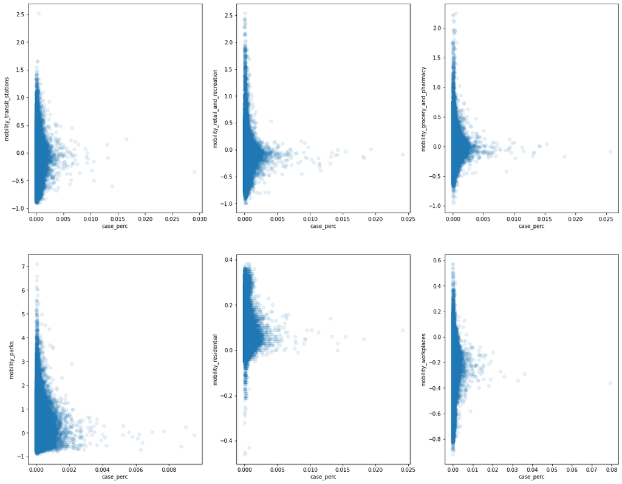

```python
plt.figure(figsize=(20, 16))

plt.subplot(2, 3, 1)
plt.scatter(b1_1["case_perc"], b1_1["mobility_transit_stations"], alpha=0.1)
plt.xlabel("case_perc")
# plt.xscale("symlog")
plt.ylabel("mobility_transit_stations")
# plt.yscale("symlog")

plt.subplot(2, 3, 2)
plt.scatter(b1_1["case_perc"], b1_1["mobility_retail_and_recreation"], alpha=0.1)
plt.xlabel("case_perc")
# plt.xscale("symlog")
plt.ylabel("mobility_retail_and_recreation")
# plt.yscale("symlog")

plt.subplot(2, 3, 3)
plt.scatter(b1_1["case_perc"], b1_1["mobility_grocery_and_pharmacy"], alpha=0.1)
plt.xlabel("case_perc")
# plt.xscale("symlog")
plt.ylabel("mobility_grocery_and_pharmacy")
# plt.yscale("symlog")

plt.subplot(2, 3, 4)
plt.scatter(b1_1["case_perc"], b1_1["mobility_parks"], alpha=0.1)
plt.xlabel("case_perc")
# plt.xscale("symlog")
plt.ylabel("mobility_parks")
# plt.yscale("symlog")

plt.subplot(2, 3, 5)
plt.scatter(b1_1["case_perc"], b1_1["mobility_residential"], alpha=0.1)
plt.xlabel("case_perc")
# plt.xscale("symlog")
plt.ylabel("mobility_residential")
# plt.yscale("symlog")

plt.subplot(2, 3, 6)
plt.scatter(b1_1["case_perc"], b1_1["mobility_workplaces"], alpha=0.1)
plt.xlabel("case_perc")
# plt.xscale("symlog")
plt.ylabel("mobility_workplaces")
# plt.yscale("symlog")
```

```python
%%bigquery --project $project_id b1_2

SELECT    date, c.location_key,
          log(p.TOT_POP) AS l_tot_pop, new_confirmed,
          new_confirmed/p.TOT_POP AS case_perc,
          mobility_transit_stations/100 AS mobility_transit_stations,
          mobility_retail_and_recreation/100 AS mobility_retail_and_recreation,
          mobility_grocery_and_pharmacy/100 AS mobility_grocery_and_pharmacy,
          mobility_parks/100 AS mobility_parks
FROM      `cs145-proj-3.covid.covid` AS c,
          `cs145-proj-3.covid.pop_est2019` AS p
WHERE     p.location_key = c.location_key
          AND p.AGEGRP = 0
          AND c.subregion2_code IS NOT NULL
          AND date >= "2020-04-01"
          AND date <= "2020-11-06"
          AND c.new_confirmed > 0
```

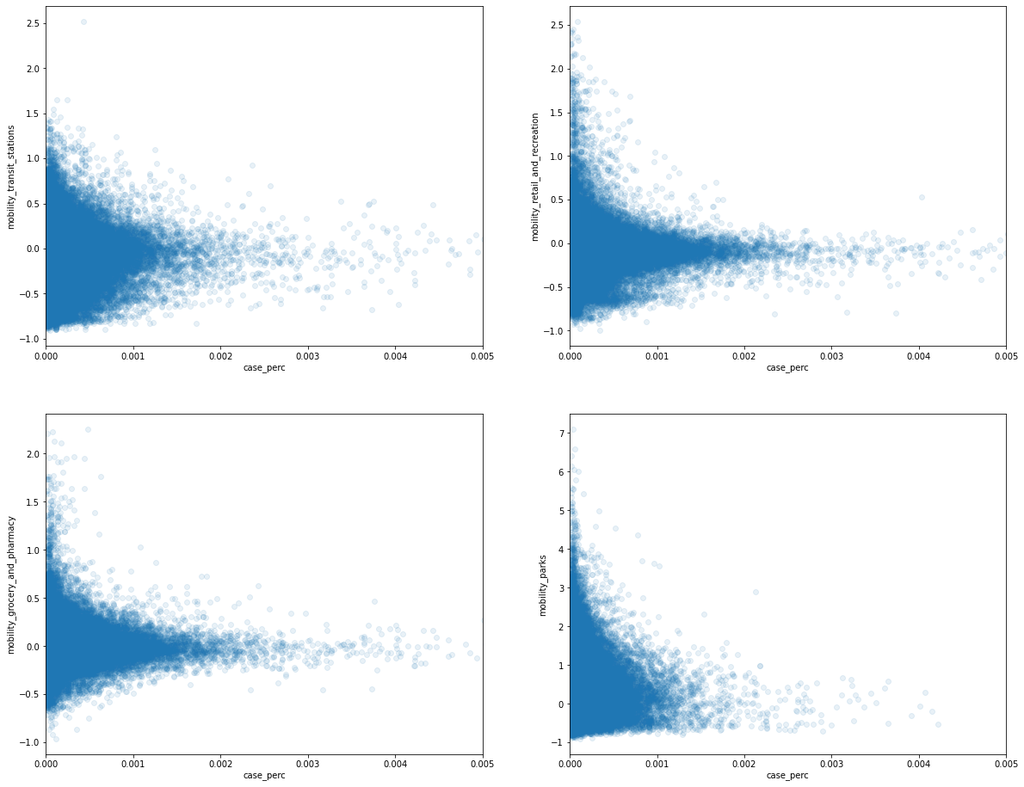

```python
plt.figure(figsize=(20, 16))

plt.subplot(2, 2, 1)
plt.scatter(b1_2["case_perc"], b1_2["mobility_transit_stations"], alpha=0.1)
plt.xlabel("case_perc")
plt.xlim((0, 0.005))
# plt.xscale("symlog")
plt.ylabel("mobility_transit_stations")
# plt.yscale("symlog")

plt.subplot(2, 2, 2)
plt.scatter(b1_2["case_perc"], b1_2["mobility_retail_and_recreation"], alpha=0.1)
plt.xlabel("case_perc")
plt.xlim((0, 0.005))
# plt.xscale("symlog")
plt.ylabel("mobility_retail_and_recreation")
# plt.yscale("symlog")

plt.subplot(2, 2, 3)
plt.scatter(b1_2["case_perc"], b1_2["mobility_grocery_and_pharmacy"], alpha=0.1)
plt.xlabel("case_perc")
plt.xlim((0, 0.005))
# plt.xscale("symlog")
plt.ylabel("mobility_grocery_and_pharmacy")
# plt.yscale("symlog")

plt.subplot(2, 2, 4)
plt.scatter(b1_2["case_perc"], b1_2["mobility_parks"], alpha=0.1)
plt.xlabel("case_perc")
plt.xlim((0, 0.005))
# plt.xscale("symlog")
plt.ylabel("mobility_parks")
# plt.yscale("symlog")
```

### c. COVID Matrices

*The exploration of COVID matrices takes three steps:*

1. County level new and cumulative confirmed cases are compared with its own historical data.
2. State level COVID matrices like culmulative tested, and culmulative recovered are compared with local county confirmed cases.
3. Infection rate of all neighboring counties, as well as infection rate of the cloests county, are compared with local confirmed cases.

*It is found that:*

- As expected, cumulative confirmed is very highly correlated with historical cumulative confirmed, with correlation of lag21 > 0.988.
- Cumulative confirmed is fairly highly correlated with cumlative deceased, with correlation > 0.818. And with historical cumlative deceased, the correlation drops gradually with time lag, reaching < 0.8 at dlag16.
- The correlation between new confimred, new deceased and cumulative confirmed are weak.
- Cumulative recovered and cumlative tested are only released at state levle. They show no correlation with county level cumlative confirmed.
- Infection rate of all neighboring counties shows fair correlation with local county infection rate (correlation > 0.780). However, when breaking down into months, the highest correlation is in March, and it drops to as low as 0.42 in June.
- Infection rate of nearest neighboring county shows mild correlation with local county infection rate (correlation > 0.665)

#### c1. Daily and Cumulative Cases

```python
%%bigquery --project $project_id c1

SELECT    new_confirmed,
          new_deceased,
          cumulative_confirmed,
          cumulative_deceased
FROM      `cs145-proj-3.covid.covid`
WHERE     subregion2_name IS NOT NULL
          AND date >= "2020-03-01"
          AND date <= "2020-11-07"
          AND new_confirmed >= 0
          AND new_deceased >= 0
```

[figure not shown]

```python
plt.figure(figsize=(20, 16))

plt.subplot(2, 2, 1)
plt.scatter(c1["new_deceased"], c1["new_confirmed"], alpha=0.1)
plt.xlabel("new_deceased")
# plt.xscale("symlog")
plt.ylabel("new_confirmed")
plt.yscale("symlog")

plt.subplot(2, 2, 2)
plt.scatter(c1["cumulative_confirmed"], c1["new_confirmed"], alpha=0.1)
plt.xlabel("cumulative_deceased")
plt.xscale("symlog")
plt.ylabel("new_confirmed")
plt.yscale("symlog")

plt.subplot(2, 2, 3)
plt.scatter(c1["new_deceased"], c1["cumulative_confirmed"], alpha=0.1)
plt.xlabel("new_deceased")
# plt.xscale("symlog")
plt.ylabel("cumulative_confirmed")
plt.yscale("symlog")

plt.subplot(2, 2, 4)
plt.scatter(c1["cumulative_deceased"], c1["cumulative_confirmed"], alpha=0.1)
plt.xlabel("cumulative_deceased")
# plt.xscale("symlog")
plt.ylabel("cumulative_confirmed")
plt.yscale("symlog")
```

```python
%%bigquery --project $project_id

SELECT    CORR(new_confirmed, new_deceased) AS cor1,
          CORR(cumulative_confirmed, new_confirmed) AS cor2,
          CORR(cumulative_confirmed, new_deceased) AS cor3,
          CORR(cumulative_confirmed, cumulative_deceased) AS cor4
FROM      `cs145-proj-3.covid.covid`
WHERE     subregion2_name IS NOT NULL
          AND date >= "2020-03-01"
          AND date <= "2020-11-07"
          AND new_confirmed >= 0
          AND new_deceased >= 0
```

|  | cor1 | cor2 | cor3 | cor4 |
| --- | --- | --- | --- | --- |
| 0 | 0.500668 | 0.614972 | 0.352617 | 0.818307 |

```python
%%bigquery --project $project_id

SELECT    CORR(cumulative_confirmed, lag1) AS cor_lag1,
          CORR(cumulative_confirmed, lag2) AS cor_lag2,
          CORR(cumulative_confirmed, lag3) AS cor_lag3,
          CORR(cumulative_confirmed, lag4) AS cor_lag4,
          CORR(cumulative_confirmed, lag5) AS cor_lag5,
          CORR(cumulative_confirmed, lag6) AS cor_lag6,
          CORR(cumulative_confirmed, lag7) AS cor_lag7,
          CORR(cumulative_confirmed, lag8) AS cor_lag8,
          CORR(cumulative_confirmed, lag9) AS cor_lag9,
          CORR(cumulative_confirmed, lag10) AS cor_lag10,
          CORR(cumulative_confirmed, lag11) AS cor_lag11,
          CORR(cumulative_confirmed, lag12) AS cor_lag12,
          CORR(cumulative_confirmed, lag13) AS cor_lag13,
          CORR(cumulative_confirmed, lag14) AS cor_lag14,
          CORR(cumulative_confirmed, lag15) AS cor_lag15,
          CORR(cumulative_confirmed, lag16) AS cor_lag16,
          CORR(cumulative_confirmed, lag17) AS cor_lag17,
          CORR(cumulative_confirmed, lag18) AS cor_lag18,
          CORR(cumulative_confirmed, lag19) AS cor_lag19,
          CORR(cumulative_confirmed, lag20) AS cor_lag20,
          CORR(cumulative_confirmed, lag21) AS cor_lag21
FROM
(SELECT   cumulative_confirmed
          LAG(cumulative_confirmed,1) OVER (PARTITION BY location_key ORDER BY date) AS lag1,
          LAG(cumulative_confirmed,2) OVER (PARTITION BY location_key ORDER BY date) AS lag2,
          LAG(cumulative_confirmed,3) OVER (PARTITION BY location_key ORDER BY date) AS lag3,
          LAG(cumulative_confirmed,4) OVER (PARTITION BY location_key ORDER BY date) AS lag4,
          LAG(cumulative_confirmed,5) OVER (PARTITION BY location_key ORDER BY date) AS lag5,
          LAG(cumulative_confirmed,6) OVER (PARTITION BY location_key ORDER BY date) AS lag6,
          LAG(cumulative_confirmed,7) OVER (PARTITION BY location_key ORDER BY date) AS lag7,
          LAG(cumulative_confirmed,8) OVER (PARTITION BY location_key ORDER BY date) AS lag8,
          LAG(cumulative_confirmed,9) OVER (PARTITION BY location_key ORDER BY date) AS lag9,
          LAG(cumulative_confirmed,10) OVER (PARTITION BY location_key ORDER BY date) AS lag10,
          LAG(cumulative_confirmed,11) OVER (PARTITION BY location_key ORDER BY date) AS lag11,
          LAG(cumulative_confirmed,12) OVER (PARTITION BY location_key ORDER BY date) AS lag12,
          LAG(cumulative_confirmed,13) OVER (PARTITION BY location_key ORDER BY date) AS lag13,
          LAG(cumulative_confirmed,14) OVER (PARTITION BY location_key ORDER BY date) AS lag14,
          LAG(cumulative_confirmed,15) OVER (PARTITION BY location_key ORDER BY date) AS lag15,
          LAG(cumulative_confirmed,16) OVER (PARTITION BY location_key ORDER BY date) AS lag16,
          LAG(cumulative_confirmed,17) OVER (PARTITION BY location_key ORDER BY date) AS lag17,
          LAG(cumulative_confirmed,18) OVER (PARTITION BY location_key ORDER BY date) AS lag18,
          LAG(cumulative_confirmed,19) OVER (PARTITION BY location_key ORDER BY date) AS lag19,
          LAG(cumulative_confirmed,20) OVER (PARTITION BY location_key ORDER BY date) AS lag20,
          LAG(cumulative_confirmed,21) OVER (PARTITION BY location_key ORDER BY date) AS lag21
FROM      `cs145-proj-3.covid.covid`
WHERE     subregion2_name IS NOT NULL
          AND date >= "2020-03-01"
          AND date <= "2020-11-07"
          AND new_confirmed >= 0
          AND new_deceased >= 0)
```

|  | cor_lag1 | cor_lag2 | cor_lag3 | cor_lag4 | cor_lag5 | cor_lag6 | cor_lag7 | cor_lag8 | cor_lag9 | cor_lag10 | cor_lag11 | cor_lag12 | cor_lag13 | cor_lag14 | cor_lag15 | cor_lag16 | cor_lag17 | cor_lag18 | cor_lag19 | cor_lag20 | cor_lag21 |
| --- | --- | --- | --- | --- | --- | --- | --- | --- | --- | --- | --- | --- | --- | --- | --- | --- | --- | --- | --- | --- | --- |
| 0 | 0.99996 | 0.999867 | 0.999722 | 0.999525 | 0.999276 | 0.998975 | 0.99862 | 0.998211 | 0.997748 | 0.997235 | 0.99667 | 0.996054 | 0.995387 | 0.994667 | 0.993894 | 0.99307 | 0.992196 | 0.991272 | 0.990301 | 0.989281 | 0.988213 |

```python
%%bigquery --project $project_id

SELECT    CORR(cumulative_confirmed, dlag1) AS cor_dlag1,
          CORR(cumulative_confirmed, dlag2) AS cor_dlag2,
          CORR(cumulative_confirmed, dlag3) AS cor_dlag3,
          CORR(cumulative_confirmed, dlag4) AS cor_dlag4,
          CORR(cumulative_confirmed, dlag5) AS cor_dlag5,
          CORR(cumulative_confirmed, dlag6) AS cor_dlag6,
          CORR(cumulative_confirmed, dlag7) AS cor_dlag7,
          CORR(cumulative_confirmed, dlag8) AS cor_dlag8,
          CORR(cumulative_confirmed, dlag9) AS cor_dlag9,
          CORR(cumulative_confirmed, dlag10) AS cor_dlag10,
          CORR(cumulative_confirmed, dlag11) AS cor_dlag11,
          CORR(cumulative_confirmed, dlag12) AS cor_dlag12,
          CORR(cumulative_confirmed, dlag13) AS cor_dlag13,
          CORR(cumulative_confirmed, dlag14) AS cor_dlag14,
          CORR(cumulative_confirmed, dlag15) AS cor_dlag15,
          CORR(cumulative_confirmed, dlag16) AS cor_dlag16,
          CORR(cumulative_confirmed, dlag17) AS cor_dlag17,
          CORR(cumulative_confirmed, dlag18) AS cor_dlag18,
          CORR(cumulative_confirmed, dlag19) AS cor_dlag19,
          CORR(cumulative_confirmed, dlag20) AS cor_dlag20,
          CORR(cumulative_confirmed, dlag21) AS cor_dlag21
FROM
(SELECT   cumulative_confirmed,
          LAG(cumulative_deceased,1) OVER (PARTITION BY location_key ORDER BY date) AS dlag1,
          LAG(cumulative_deceased,2) OVER (PARTITION BY location_key ORDER BY date) AS dlag2,
          LAG(cumulative_deceased,3) OVER (PARTITION BY location_key ORDER BY date) AS dlag3,
          LAG(cumulative_deceased,4) OVER (PARTITION BY location_key ORDER BY date) AS dlag4,
          LAG(cumulative_deceased,5) OVER (PARTITION BY location_key ORDER BY date) AS dlag5,
          LAG(cumulative_deceased,6) OVER (PARTITION BY location_key ORDER BY date) AS dlag6,
          LAG(cumulative_deceased,7) OVER (PARTITION BY location_key ORDER BY date) AS dlag7,
          LAG(cumulative_deceased,8) OVER (PARTITION BY location_key ORDER BY date) AS dlag8,
          LAG(cumulative_deceased,9) OVER (PARTITION BY location_key ORDER BY date) AS dlag9,
          LAG(cumulative_deceased,10) OVER (PARTITION BY location_key ORDER BY date) AS dlag10,
          LAG(cumulative_deceased,11) OVER (PARTITION BY location_key ORDER BY date) AS dlag11,
          LAG(cumulative_deceased,12) OVER (PARTITION BY location_key ORDER BY date) AS dlag12,
          LAG(cumulative_deceased,13) OVER (PARTITION BY location_key ORDER BY date) AS dlag13,
          LAG(cumulative_deceased,14) OVER (PARTITION BY location_key ORDER BY date) AS dlag14,
          LAG(cumulative_deceased,15) OVER (PARTITION BY location_key ORDER BY date) AS dlag15,
          LAG(cumulative_deceased,16) OVER (PARTITION BY location_key ORDER BY date) AS dlag16,
          LAG(cumulative_deceased,17) OVER (PARTITION BY location_key ORDER BY date) AS dlag17,
          LAG(cumulative_deceased,18) OVER (PARTITION BY location_key ORDER BY date) AS dlag18,
          LAG(cumulative_deceased,19) OVER (PARTITION BY location_key ORDER BY date) AS dlag19,
          LAG(cumulative_deceased,20) OVER (PARTITION BY location_key ORDER BY date) AS dlag20,
          LAG(cumulative_deceased,21) OVER (PARTITION BY location_key ORDER BY date) AS dlag21
FROM      `cs145-proj-3.covid.covid`
WHERE     subregion2_name IS NOT NULL
          AND date >= "2020-03-01"
          AND date <= "2020-11-07"
          AND new_confirmed >= 0
          AND new_deceased >= 0)
```

|  | cor_dlag1 | cor_dlag2 | cor_dlag3 | cor_dlag4 | cor_dlag5 | cor_dlag6 | cor_dlag7 | cor_dlag8 | cor_dlag9 | cor_dlag10 | cor_dlag11 | cor_dlag12 | cor_dlag13 | cor_dlag14 | cor_dlag15 | cor_dlag16 | cor_dlag17 | cor_dlag18 | cor_dlag19 | cor_dlag20 | cor_dlag21 |
| --- | --- | --- | --- | --- | --- | --- | --- | --- | --- | --- | --- | --- | --- | --- | --- | --- | --- | --- | --- | --- | --- |
| 0 | 0.817414 | 0.816477 | 0.81551 | 0.814503 | 0.813459 | 0.812375 | 0.811243 | 0.810063 | 0.808842 | 0.80758 | 0.806277 | 0.804935 | 0.803555 | 0.802131 | 0.800664 | 0.79916 | 0.797617 | 0.796037 | 0.794428 | 0.792788 | 0.791106 |

#### c2. State Level Correlation

```python
%%bigquery --project $project_id c2

SELECT    c.date, c.location_key,
          c.new_confirmed,
          c.new_deceased,
          c.cumulative_confirmed,
          c.cumulative_deceased,
          s.cumulative_recovered AS state_cumulative_recovered,
          s.cumulative_tested AS state_cumulative_tested

FROM

(SELECT   date, location_key,
          LEFT(location_key,5) AS state,
          new_confirmed,
          new_deceased,
          cumulative_confirmed,
          cumulative_deceased
FROM      `cs145-proj-3.covid.covid`
WHERE     subregion2_name IS NOT NULL
          AND date >= "2020-03-01"
          AND date <= "2020-11-07"
          AND new_confirmed >= 0
          AND new_deceased >= 0) AS c

LEFT JOIN

(SELECT   date, location_key,
          cumulative_recovered,
          cumulative_tested
FROM      `cs145-proj-3.covid.covid`
WHERE     subregion2_name IS NULL
          AND subregion1_name IS NOT NULL
          AND date >= "2020-03-01"
          AND date <= "2020-11-07") AS s

ON        c.date = s.date
          AND c.state = s.location_key
```

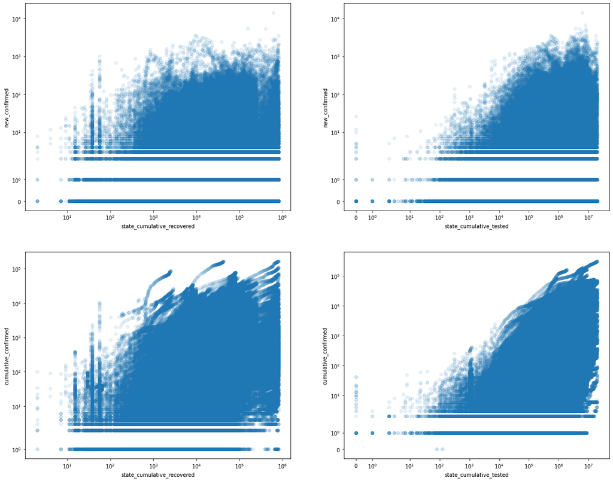

```python
plt.figure(figsize=(20, 16))

plt.subplot(2, 2, 1)
plt.scatter(c2["state_cumulative_recovered"], c2["new_confirmed"], alpha=0.1)
plt.xlabel("state_cumulative_recovered")
plt.xscale("symlog")
plt.ylabel("new_confirmed")
plt.yscale("symlog")

plt.subplot(2, 2, 2)
plt.scatter(c2["state_cumulative_tested"], c2["new_confirmed"], alpha=0.1)
plt.xlabel("state_cumulative_tested")
plt.xscale("symlog")
plt.ylabel("new_confirmed")
plt.yscale("symlog")

plt.subplot(2, 2, 3)
plt.scatter(c2["state_cumulative_recovered"], c2["cumulative_confirmed"], alpha=0.1)
plt.xlabel("state_cumulative_recovered")
plt.xscale("symlog")
plt.ylabel("cumulative_confirmed")
plt.yscale("symlog")

plt.subplot(2, 2, 4)
plt.scatter(c2["state_cumulative_tested"], c2["cumulative_confirmed"], alpha=0.1)
plt.xlabel("state_cumulative_tested")
plt.xscale("symlog")
plt.ylabel("cumulative_confirmed")
plt.yscale("symlog")
```

```python
%%bigquery --project $project_id

SELECT    CORR(new_confirmed, cumulative_recovered) AS cor1,
          CORR(new_confirmed, cumulative_tested) AS cor2,
          CORR(cumulative_confirmed, cumulative_recovered) AS cor3,
          CORR(cumulative_confirmed, cumulative_tested) AS cor4

FROM

(SELECT   date, location_key,
          LEFT(location_key,5) AS state,
          new_confirmed,
          new_deceased,
          cumulative_confirmed,
          cumulative_deceased
FROM      `cs145-proj-3.covid.covid`
WHERE     subregion2_name IS NOT NULL
          AND date >= "2020-03-01"
          AND date <= "2020-11-07"
          AND new_confirmed >= 0
          AND new_deceased >= 0) AS c

LEFT JOIN

(SELECT   date, location_key,
          cumulative_recovered,
          cumulative_tested
FROM      `cs145-proj-3.covid.covid`
WHERE     subregion2_name IS NULL
          AND subregion1_name IS NOT NULL
          AND date >= "2020-03-01"
          AND date <= "2020-11-07") AS s

ON        c.date = s.date
          AND c.state = s.location_key
```

|  | cor1 | cor2 | cor3 | cor4 |
| --- | --- | --- | --- | --- |
| 0 | 0.068231 | 0.123368 | 0.118624 | 0.243189 |

#### c3. Neighboring County cases

```python
SELECT   date,
         location_key,
         rate_infect,
         SUM(neighbors_cumulative_confirmed) / SUM(neighbors_pop) AS avg_neighbors_rate_infect
FROM

(SELECT   n1.date, n1.location_key,
          n1.cumulative_confirmed/n1.pop AS rate_infect,
          n2.location_key AS neighbors_location_key,
          n2.cumulative_confirmed AS neighbors_cumulative_confirmed,
          n2.pop AS neighbors_pop
FROM
(SELECT    c.date, c.location_key, c.cumulative_confirmed, p.pop
FROM      (SELECT   date, location_key, subregion1_name,
                    subregion2_name,
                    cumulative_confirmed
          FROM      `cs145-proj-3.covid.covid`
          WHERE     subregion2_code IS NOT NULL
                    AND date >= "2020-03-01"
                    AND date <= "2020-11-07") AS c
          LEFT JOIN
          (SELECT   location_key, TOT_POP AS pop
          FROM      `cs145-proj-3.covid.pop_est2019`
          WHERE     AGEGRP = 0) AS p
ON     p.location_key = c.location_key) AS n1,
(SELECT    c.date, c.location_key, c.cumulative_confirmed, p.pop
FROM      (SELECT   date, location_key, subregion1_name,
                    subregion2_name,
                    cumulative_confirmed
          FROM      `cs145-proj-3.covid.covid`
          WHERE     subregion2_code IS NOT NULL
                    AND date >= "2020-03-01"
                    AND date <= "2020-11-07") AS c
          LEFT JOIN
          (SELECT   location_key, TOT_POP AS pop
          FROM      `cs145-proj-3.covid.pop_est2019`
          WHERE     AGEGRP = 0) AS p
ON      p.location_key = c.location_key) AS n2,
        (SELECT county, state, county_fips_code, neighbors_fips_code
          FROM  cs145-proj-3.covid.adj_counties,
                UNNEST(adj_counties.neighbors_fips_code) AS neighbors_fips_code)AS adj
WHERE   n1.date = n2.date
        AND RIGHT(n1.location_key,5) = adj.county_fips_code
        AND RIGHT(n2.location_key,5) = adj.neighbors_fips_code)

GROUP BY  date, location_key, rate_infect
```

```python
%%bigquery --project $project_id c3_1

SELECT  rate_infect, avg_neighbors_rate_infect
FROM    `cs145-proj-3.covid.avg_neighbors_rate_infect`
```

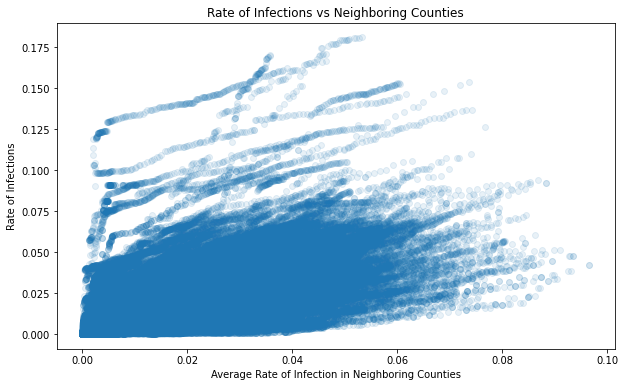

```python
plt.figure(figsize=(10, 6))
plt.scatter(c3_1["avg_neighbors_rate_infect"], c3_1["rate_infect"], alpha=0.1)
plt.title("Rate of Infections vs Neighboring Counties")
plt.xlabel("Average Rate of Infection in Neighboring Counties")
# plt.xscale("symlog")
plt.ylabel("Rate of Infections")
# plt.yscale("symlog")
```

```python
%%bigquery --project $project_id

SELECT  CORR(rate_infect, avg_neighbors_rate_infect) AS cor,
        CORR(rate_infect, IF(EXTRACT(MONTH FROM date) = 3, avg_neighbors_rate_infect, NULL)) AS cor_mar,
        CORR(rate_infect, IF(EXTRACT(MONTH FROM date) = 4, avg_neighbors_rate_infect, NULL)) AS cor_apr,
        CORR(rate_infect, IF(EXTRACT(MONTH FROM date) = 5, avg_neighbors_rate_infect, NULL)) AS cor_may,
        CORR(rate_infect, IF(EXTRACT(MONTH FROM date) = 6, avg_neighbors_rate_infect, NULL)) AS cor_jun,
        CORR(rate_infect, IF(EXTRACT(MONTH FROM date) = 7, avg_neighbors_rate_infect, NULL)) AS cor_jul,
        CORR(rate_infect, IF(EXTRACT(MONTH FROM date) = 8, avg_neighbors_rate_infect, NULL)) AS cor_aug,
        CORR(rate_infect, IF(EXTRACT(MONTH FROM date) = 9, avg_neighbors_rate_infect, NULL)) AS cor_sep,
        CORR(rate_infect, IF(EXTRACT(MONTH FROM date) = 10, avg_neighbors_rate_infect, NULL)) AS cor_oct,
        CORR(rate_infect, IF(EXTRACT(MONTH FROM date) = 11, avg_neighbors_rate_infect, NULL)) AS cor_nov
FROM `cs145-proj-3.covid.avg_neighbors_rate_infect`
```

|  | cor | cor_mar | cor_apr | cor_may | cor_jun | cor_jul | cor_aug | cor_sep | cor_oct | cor_nov |
| --- | --- | --- | --- | --- | --- | --- | --- | --- | --- | --- |
| 0 | 0.779583 | 0.749321 | 0.664132 | 0.436731 | 0.416788 | 0.517521 | 0.622519 | 0.630837 | 0.643474 | 0.650135 |

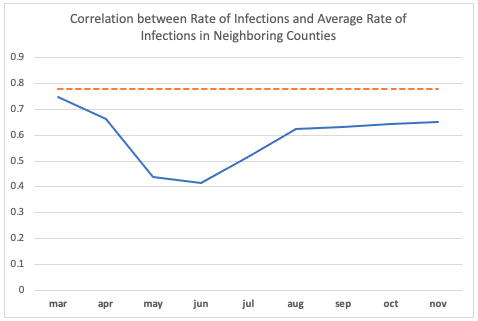

```python
%%bigquery --project $project_id c3_2

SELECT  rate_infect, nearest_neighbors_rate_infect
FROM    `cs145-proj-3.covid.nearest_neighbors_rate_infect`
```

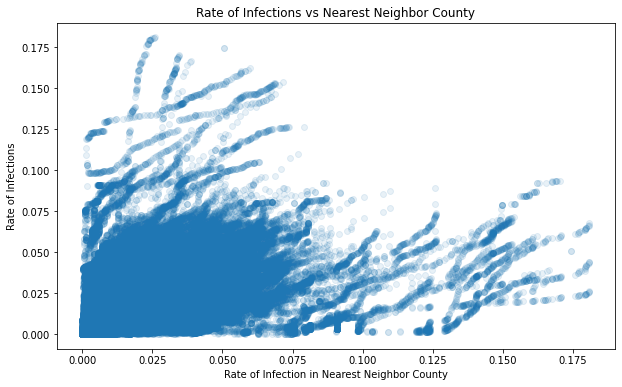

```python
plt.figure(figsize=(10, 6))
plt.scatter(c3_2["nearest_neighbors_rate_infect"], c3_2["rate_infect"], alpha=0.1)
plt.title("Rate of Infections vs Nearest Neighbor County")
plt.xlabel("Rate of Infection in Nearest Neighbor County")
# plt.xscale("symlog")
plt.ylabel("Rate of Infections")
# plt.yscale("symlog")
```

```python
%%bigquery --project $project_id

SELECT  CORR(rate_infect, nearest_neighbors_rate_infect) AS cor
FROM `cs145-proj-3.covid.nearest_neighbors_rate_infect`
```

|  | cor |
| --- | --- |
| 0 | 0.665146 |

## Data Prediction

*Base on above explorations, there are a few sets of features related useful for predicting number of covid infection cases in county level.*

- **Population:** Total population by sex, age, race
- **Mobility:**: Mobility for transit stations, retail and recreation, grocery andpharmacy, and parks
- **Covid Matrices:** Historical cumulative confirmed and cumulated deceased.

*After trying out different combinations, below features give the best evaluation result:*

- **Historical Culmulative Confirmed:** lag1 to lag28 represents culmulative confirmed cases from yesterday (lag1) to 28 days ago (lag28)
- **Historical Culmulative Deceased:** dlag1 to dlag14 represents culmulative deceased cases from yesterday (dlag1) to 14 days ago (dlag14)
- **Population:** a_1 to a_18 represents population by age group from age 0 to 4 (a_1) to age 85 or above (a_18)

### a. Create table for modeling

*A table is created to faciliate modeling and evaluation. Code in Appendix.*

### b. Training on Apr - Aug Data

```python
%%bigquery --project $project_id

CREATE OR REPLACE MODEL `covid.covid_mod2`
OPTIONS (model_type="LINEAR_REG") AS
SELECT        cumulative_confirmed AS label,

              lag1, lag2, lag3, lag4, lag5, lag6, lag7,
              lag8, lag9, lag10, lag11, lag12, lag13, lag14,
              lag15, lag16, lag17, lag18, lag19, lag20, lag21,
              lag22, lag23, lag24, lag25, lag26, lag27, lag28,

              dlag1, dlag2, dlag3, dlag4, dlag5, dlag6, dlag7,
              dlag8, dlag9, dlag10, dlag11, dlag12, dlag13, dlag14,

              a_1, a_2, a_3, a_4, a_5, a_6, a_7, a_8, a_9, a_10,
              a_11, a_12, a_13, a_14, a_15, a_16, a_17, a_18

FROM          `cs145-proj-3.covid.covid_ml`
WHERE         date >= "2020-04-01"
              AND date < "2020-09-01"
              AND cumulative_confirmed IS NOT NULL
```

```python
%%bigquery --project $project_id

# Run cell to view training stats

SELECT
  *
FROM
  ML.TRAINING_INFO(MODEL `covid.covid_mod2`)
```

|  | training_run | iteration | loss | eval_loss | learning_rate | duration_ms |
| --- | --- | --- | --- | --- | --- | --- |
| 0 | 0 | 0 | 2839.1333 | 2901.481335 | None | 24191 |

### c. Evaluate on Sep Data

```python
%%bigquery --project $project_id

SELECT
  *
FROM
  ML.EVALUATE(MODEL `covid.covid_mod2`, (
SELECT        cumulative_confirmed AS label,

              lag1, lag2, lag3, lag4, lag5, lag6, lag7,
              lag8, lag9, lag10, lag11, lag12, lag13, lag14,
              lag15, lag16, lag17, lag18, lag19, lag20, lag21,
              lag22, lag23, lag24, lag25, lag26, lag27, lag28,

              dlag1, dlag2, dlag3, dlag4, dlag5, dlag6, dlag7,
              dlag8, dlag9, dlag10, dlag11, dlag12, dlag13, dlag14,

              a_1, a_2, a_3, a_4, a_5, a_6, a_7, a_8, a_9, a_10,
              a_11, a_12, a_13, a_14, a_15, a_16, a_17, a_18

FROM          `cs145-proj-3.covid.covid_ml`
WHERE         date >= "2020-09-01"
              AND date < "2020-10-01"
              AND cumulative_confirmed IS NOT NULL))
```

|  | mean_absolute_error | mean_squared_error | mean_squared_log_error | median_absolute_error | r2_score | explained_variance |
| --- | --- | --- | --- | --- | --- | --- |
| 0 | 7.518147 | 3107.466828 | 0.004441 | 2.082388 | 0.999959 | 0.999959 |

### d. Evaluate on Oct Data (Test set)

```python
%%bigquery --project $project_id

SELECT
  *
FROM
  ML.EVALUATE(MODEL `covid.covid_mod2`, (
SELECT        cumulative_confirmed AS label,

              lag1, lag2, lag3, lag4, lag5, lag6, lag7,
              lag8, lag9, lag10, lag11, lag12, lag13, lag14,
              lag15, lag16, lag17, lag18, lag19, lag20, lag21,
              lag22, lag23, lag24, lag25, lag26, lag27, lag28,

              dlag1, dlag2, dlag3, dlag4, dlag5, dlag6, dlag7,
              dlag8, dlag9, dlag10, dlag11, dlag12, dlag13, dlag14,

              a_1, a_2, a_3, a_4, a_5, a_6, a_7, a_8, a_9, a_10,
              a_11, a_12, a_13, a_14, a_15, a_16, a_17, a_18

FROM          `cs145-proj-3.covid.covid_ml`
WHERE         date >= "2020-10-01"
              AND date < "2020-11-01"
              AND cumulative_confirmed IS NOT NULL))
```

|  | mean_absolute_error | mean_squared_error | mean_squared_log_error | median_absolute_error | r2_score | explained_variance |
| --- | --- | --- | --- | --- | --- | --- |
| 0 | 9.630026 | 1400.487659 | 0.003674 | 2.818534 | 0.999986 | 0.999986 |

### e. Prediction on Nov 1-7 Data

```python
%%bigquery --project $project_id

SELECT
  date,
  location_key,
  predicted_label,
  cumulative_confirmed AS ground_truth

FROM

ML.PREDICT(MODEL `covid.covid_mod2`, (

SELECT        date, location_key, cumulative_confirmed,

              lag1, lag2, lag3, lag4, lag5, lag6, lag7,
              lag8, lag9, lag10, lag11, lag12, lag13, lag14,
              lag15, lag16, lag17, lag18, lag19, lag20, lag21,
              lag22, lag23, lag24, lag25, lag26, lag27, lag28,

              dlag1, dlag2, dlag3, dlag4, dlag5, dlag6, dlag7,
              dlag8, dlag9, dlag10, dlag11, dlag12, dlag13, dlag14,

              a_1, a_2, a_3, a_4, a_5, a_6, a_7, a_8, a_9, a_10,
              a_11, a_12, a_13, a_14, a_15, a_16, a_17, a_18

FROM          `cs145-proj-3.covid.covid_ml`
WHERE         date >= "2020-11-01"
              AND date <= "2020-11-07"
              AND lag1 > 0))                                # using lag1 to remove cumulative_confirmed cases in prediction
```

|  | date | location_key | predicted_label | ground_truth |
| --- | --- | --- | --- | --- |
| 0 | 2020-11-01 | US_AR_05107 | 783.421317 | 781 |
| 1 | 2020-11-01 | US_CA_06063 | 83.639661 | 85 |
| 2 | 2020-11-01 | US_CA_06073 | 57157.080013 | 57165 |
| 3 | 2020-11-01 | US_CA_06113 | 3308.017849 | 3303 |
| 4 | 2020-11-01 | US_GA_13169 | 681.598674 | 685 |
| ... | ... | ... | ... | ... |
| 21954 | 2020-11-07 | US_VT_50013 | 19.794578 | 20 |
| 21955 | 2020-11-07 | US_WI_55023 | 485.137214 | 494 |
| 21956 | 2020-11-07 | US_WI_55079 | 51421.958531 | 51739 |
| 21957 | 2020-11-07 | US_WV_54009 | 278.689644 | 282 |
| 21958 | 2020-11-07 | US_WV_54043 | 296.743081 | 298 |

21959 rows × 4 columns

## Conclusion

*Some further investigation and development suggestions:*

1. Adding time lag treatment on four mobility indices ("Transit stations", "Grocery & pharmacy", "Retail & recreation" and "Parks") and retrain and reevaluate models.
2. Find the relative best model without using most recent data (lag1, lag2, etc...) but still retaining a level of accuracy in prediction. That would be more practical in production case.

# Appendix

### Reference for Project Overview

```python
# to calculate error rate of model prediction

%%bigquery --project $project_id

SELECT AVG(abs(ground_truth - predicted_label) / ground_truth) * 100 AS err_rate

FROM

(SELECT
  date,
  location_key,
  predicted_label,
  cumulative_confirmed AS ground_truth

FROM

ML.PREDICT(MODEL `covid.covid_mod2`, (

SELECT        date, location_key, cumulative_confirmed,

              lag1, lag2, lag3, lag4, lag5, lag6, lag7,
              lag8, lag9, lag10, lag11, lag12, lag13, lag14,
              lag15, lag16, lag17, lag18, lag19, lag20, lag21,
              lag22, lag23, lag24, lag25, lag26, lag27, lag28,

              dlag1, dlag2, dlag3, dlag4, dlag5, dlag6, dlag7,
              dlag8, dlag9, dlag10, dlag11, dlag12, dlag13, dlag14,

              a_1, a_2, a_3, a_4, a_5, a_6, a_7, a_8, a_9, a_10,
              a_11, a_12, a_13, a_14, a_15, a_16, a_17, a_18

FROM          `cs145-proj-3.covid.covid_ml`
WHERE         date >= "2020-11-01"
              AND date <= "2020-11-07"
              AND lag1 > 0)))
```

|  | err_rate |
| --- | --- |
| 0 | 1.66018 |

```python
# to calculate error rate of Google prediction
# Google predicts on 7day rolling of new confirmed
# to make apple-to-apple comparison, prediction on cumulative confirmed is
# backward engineered by using predicted "new_confirmed_7day_rolling"
# n.b. ground truth of cumulative confirmed in this table is a little diviated than that in covid19_open_data

%%bigquery --project $project_id

SELECT  AVG(abs(ground_truth - predicted) / ground_truth) * 100 AS err_rate

FROM

(SELECT (cumulative_confirmed_ground_truth - new_confirmed_ground_truth + new_confirmed_7day_rolling) AS predicted,
        cumulative_confirmed_ground_truth AS ground_truth
FROM `bigquery-public-data.covid19_public_forecasts.county_14d`
WHERE   prediction_date >= "2020-11-01"
        AND prediction_date <= "2020-11-07")
        WHERE ground_truth != 0
```

|  | err_rate |
| --- | --- |
| 0 | 10.044897 |

### Reference for Data Exploration Part a5

*Sense check for race dataset.*

```python
%%bigquery --project $project_id

SELECT    MAX(all_race) AS max,
          MIN(all_race) AS min,
FROM    (SELECT     ROUND((SUM(WA_MALE) + SUM(WA_FEMALE) + SUM(BA_MALE) + SUM(BA_FEMALE) +
                    SUM(IA_MALE) + SUM(IA_FEMALE) + SUM(AA_MALE) + SUM(AA_FEMALE) +
                    SUM(NA_MALE) + SUM(NA_FEMALE)) / SUM(TOT_POP) * 100 , 2) AS single_race,

                    ROUND((SUM(TOM_MALE) + SUM(TOM_FEMALE)) / SUM(TOT_POP) * 100 , 2) AS two_or_more_races,

                    ROUND((SUM(WA_MALE) + SUM(WA_FEMALE) + SUM(BA_MALE) + SUM(BA_FEMALE) +
                    SUM(IA_MALE) + SUM(IA_FEMALE) + SUM(AA_MALE) + SUM(AA_FEMALE) +
                    SUM(NA_MALE) + SUM(NA_FEMALE)) / SUM(TOT_POP) * 100 , 2) +
                    ROUND((SUM(TOM_MALE) + SUM(TOM_FEMALE)) / SUM(TOT_POP) * 100 , 2) AS all_race
          FROM      `cs145-proj-3.covid.pop_est2019`
          GROUP BY  county_code)
```

|  | max | min |
| --- | --- | --- |
| 0 | 100.0 | 100.0 |

### Reference for Data Prediction Part a

*Creating table for model training and evaluation.*

```python
%%bigquery --project $project_id

SELECT    c.date, c.location_key, c.new_confirmed, c.cumulative_confirmed, c.cumulative_deceased,
          lag1, lag2, lag3, lag4, lag5, lag6, lag7,
          lag8, lag9, lag10, lag11, lag12, lag13, lag14,
          lag15, lag16, lag17, lag18, lag19, lag20, lag21,
          lag22, lag23, lag24, lag25, lag26, lag27, lag28,

          nlag1, nlag2, nlag3, nlag4, nlag5, nlag6, nlag7,
          nlag8, nlag9, nlag10, nlag11, nlag12, nlag13, nlag14,
          nlag15, nlag16, nlag17, nlag18, nlag19, nlag20, nlag21,

          dlag1, dlag2, dlag3, dlag4, dlag5, dlag6, dlag7,
          dlag8, dlag9, dlag10, dlag11, dlag12, dlag13, dlag14,
          dlag15, dlag16, dlag17, dlag18, dlag19, dlag20, dlag21,

          TOT_POP, TOT_MALE, TOT_FEMALE,

          a_1, a_2, a_3, a_4, a_5, a_6, a_7, a_8, a_9, a_10,
          a_11, a_12, a_13, a_14, a_15, a_16, a_17, a_18,

          WA_MALE + WA_FEMALE AS WA,
          BA_MALE + BA_FEMALE AS BA,
          IA_MALE + IA_FEMALE AS IA,
          AA_MALE + AA_FEMALE AS AA,
          NA_MALE + NA_FEMALE AS NA,
          H_MALE + H_FEMALE AS H,
          BAC_MALE + BAC_FEMALE AS BAC,
          HWA_MALE + HWA_FEMALE AS HWA,


          mobility_transit_stations, mobility_retail_and_recreation,
          mobility_grocery_and_pharmacy, mobility_parks

FROM      (SELECT   location_key, TOT_POP, TOT_MALE, TOT_FEMALE,
                    WA_MALE, WA_FEMALE, BA_MALE, BA_FEMALE,
                    IA_MALE, IA_FEMALE, AA_MALE, AA_FEMALE,
                    NA_MALE, NA_FEMALE, H_MALE, H_FEMALE,
                    BAC_MALE, BAC_FEMALE, HWA_MALE, HWA_FEMALE
          FROM      `cs145-proj-3.covid.pop_est2019`
          WHERE     AGEGRP = 0) AS p,

          (SELECT   *
          FROM      `cs145-proj-3.covid.pop_age`) AS a,

          (SELECT   date, location_key, new_confirmed, cumulative_confirmed, cumulative_deceased,
                    mobility_transit_stations, mobility_retail_and_recreation,
                    mobility_grocery_and_pharmacy, mobility_parks,

                    LAG(cumulative_confirmed,1) OVER (PARTITION BY location_key ORDER BY date) AS lag1,
                    LAG(cumulative_confirmed,2) OVER (PARTITION BY location_key ORDER BY date) AS lag2,
                    LAG(cumulative_confirmed,3) OVER (PARTITION BY location_key ORDER BY date) AS lag3,
                    LAG(cumulative_confirmed,4) OVER (PARTITION BY location_key ORDER BY date) AS lag4,
                    LAG(cumulative_confirmed,5) OVER (PARTITION BY location_key ORDER BY date) AS lag5,
                    LAG(cumulative_confirmed,6) OVER (PARTITION BY location_key ORDER BY date) AS lag6,
                    LAG(cumulative_confirmed,7) OVER (PARTITION BY location_key ORDER BY date) AS lag7,
                    LAG(cumulative_confirmed,8) OVER (PARTITION BY location_key ORDER BY date) AS lag8,
                    LAG(cumulative_confirmed,9) OVER (PARTITION BY location_key ORDER BY date) AS lag9,
                    LAG(cumulative_confirmed,10) OVER (PARTITION BY location_key ORDER BY date) AS lag10,
                    LAG(cumulative_confirmed,11) OVER (PARTITION BY location_key ORDER BY date) AS lag11,
                    LAG(cumulative_confirmed,12) OVER (PARTITION BY location_key ORDER BY date) AS lag12,
                    LAG(cumulative_confirmed,13) OVER (PARTITION BY location_key ORDER BY date) AS lag13,
                    LAG(cumulative_confirmed,14) OVER (PARTITION BY location_key ORDER BY date) AS lag14,
                    LAG(cumulative_confirmed,15) OVER (PARTITION BY location_key ORDER BY date) AS lag15,
                    LAG(cumulative_confirmed,16) OVER (PARTITION BY location_key ORDER BY date) AS lag16,
                    LAG(cumulative_confirmed,17) OVER (PARTITION BY location_key ORDER BY date) AS lag17,
                    LAG(cumulative_confirmed,18) OVER (PARTITION BY location_key ORDER BY date) AS lag18,
                    LAG(cumulative_confirmed,19) OVER (PARTITION BY location_key ORDER BY date) AS lag19,
                    LAG(cumulative_confirmed,20) OVER (PARTITION BY location_key ORDER BY date) AS lag20,
                    LAG(cumulative_confirmed,21) OVER (PARTITION BY location_key ORDER BY date) AS lag21,
                    LAG(cumulative_confirmed,22) OVER (PARTITION BY location_key ORDER BY date) AS lag22,
                    LAG(cumulative_confirmed,23) OVER (PARTITION BY location_key ORDER BY date) AS lag23,
                    LAG(cumulative_confirmed,24) OVER (PARTITION BY location_key ORDER BY date) AS lag24,
                    LAG(cumulative_confirmed,25) OVER (PARTITION BY location_key ORDER BY date) AS lag25,
                    LAG(cumulative_confirmed,26) OVER (PARTITION BY location_key ORDER BY date) AS lag26,
                    LAG(cumulative_confirmed,27) OVER (PARTITION BY location_key ORDER BY date) AS lag27,
                    LAG(cumulative_confirmed,28) OVER (PARTITION BY location_key ORDER BY date) AS lag28,

                    LAG(new_confirmed,1) OVER (PARTITION BY location_key ORDER BY date) AS nlag1,
                    LAG(new_confirmed,2) OVER (PARTITION BY location_key ORDER BY date) AS nlag2,
                    LAG(new_confirmed,3) OVER (PARTITION BY location_key ORDER BY date) AS nlag3,
                    LAG(new_confirmed,4) OVER (PARTITION BY location_key ORDER BY date) AS nlag4,
                    LAG(new_confirmed,5) OVER (PARTITION BY location_key ORDER BY date) AS nlag5,
                    LAG(new_confirmed,6) OVER (PARTITION BY location_key ORDER BY date) AS nlag6,
                    LAG(new_confirmed,7) OVER (PARTITION BY location_key ORDER BY date) AS nlag7,
                    LAG(new_confirmed,8) OVER (PARTITION BY location_key ORDER BY date) AS nlag8,
                    LAG(new_confirmed,9) OVER (PARTITION BY location_key ORDER BY date) AS nlag9,
                    LAG(new_confirmed,10) OVER (PARTITION BY location_key ORDER BY date) AS nlag10,
                    LAG(new_confirmed,11) OVER (PARTITION BY location_key ORDER BY date) AS nlag11,
                    LAG(new_confirmed,12) OVER (PARTITION BY location_key ORDER BY date) AS nlag12,
                    LAG(new_confirmed,13) OVER (PARTITION BY location_key ORDER BY date) AS nlag13,
                    LAG(new_confirmed,14) OVER (PARTITION BY location_key ORDER BY date) AS nlag14,
                    LAG(new_confirmed,15) OVER (PARTITION BY location_key ORDER BY date) AS nlag15,
                    LAG(new_confirmed,16) OVER (PARTITION BY location_key ORDER BY date) AS nlag16,
                    LAG(new_confirmed,17) OVER (PARTITION BY location_key ORDER BY date) AS nlag17,
                    LAG(new_confirmed,18) OVER (PARTITION BY location_key ORDER BY date) AS nlag18,
                    LAG(new_confirmed,19) OVER (PARTITION BY location_key ORDER BY date) AS nlag19,
                    LAG(new_confirmed,20) OVER (PARTITION BY location_key ORDER BY date) AS nlag20,
                    LAG(new_confirmed,21) OVER (PARTITION BY location_key ORDER BY date) AS nlag21,

                    LAG(cumulative_deceased,1) OVER (PARTITION BY location_key ORDER BY date) AS dlag1,
                    LAG(cumulative_deceased,2) OVER (PARTITION BY location_key ORDER BY date) AS dlag2,
                    LAG(cumulative_deceased,3) OVER (PARTITION BY location_key ORDER BY date) AS dlag3,
                    LAG(cumulative_deceased,4) OVER (PARTITION BY location_key ORDER BY date) AS dlag4,
                    LAG(cumulative_deceased,5) OVER (PARTITION BY location_key ORDER BY date) AS dlag5,
                    LAG(cumulative_deceased,6) OVER (PARTITION BY location_key ORDER BY date) AS dlag6,
                    LAG(cumulative_deceased,7) OVER (PARTITION BY location_key ORDER BY date) AS dlag7,
                    LAG(cumulative_deceased,8) OVER (PARTITION BY location_key ORDER BY date) AS dlag8,
                    LAG(cumulative_deceased,9) OVER (PARTITION BY location_key ORDER BY date) AS dlag9,
                    LAG(cumulative_deceased,10) OVER (PARTITION BY location_key ORDER BY date) AS dlag10,
                    LAG(cumulative_deceased,11) OVER (PARTITION BY location_key ORDER BY date) AS dlag11,
                    LAG(cumulative_deceased,12) OVER (PARTITION BY location_key ORDER BY date) AS dlag12,
                    LAG(cumulative_deceased,13) OVER (PARTITION BY location_key ORDER BY date) AS dlag13,
                    LAG(cumulative_deceased,14) OVER (PARTITION BY location_key ORDER BY date) AS dlag14,
                    LAG(cumulative_deceased,15) OVER (PARTITION BY location_key ORDER BY date) AS dlag15,
                    LAG(cumulative_deceased,16) OVER (PARTITION BY location_key ORDER BY date) AS dlag16,
                    LAG(cumulative_deceased,17) OVER (PARTITION BY location_key ORDER BY date) AS dlag17,
                    LAG(cumulative_deceased,18) OVER (PARTITION BY location_key ORDER BY date) AS dlag18,
                    LAG(cumulative_deceased,19) OVER (PARTITION BY location_key ORDER BY date) AS dlag19,
                    LAG(cumulative_deceased,20) OVER (PARTITION BY location_key ORDER BY date) AS dlag20,
                    LAG(cumulative_deceased,21) OVER (PARTITION BY location_key ORDER BY date) AS dlag21


          FROM      `cs145-proj-3.covid.covid`
          WHERE     subregion2_code IS NOT NULL) AS c
WHERE     p.location_key = c.location_key
          AND a.location_key = p.location_key
          AND date >= "2020-04-01"
ORDER BY  date
```